# ML_Project_Pablo_Leon

Pablo Leon (p.leon@ieee.org)

18 de agosto de 2018

## Assigment: Prediction Assignment Writeup

In this project, our goal will be to use data from accelerometers on the belt, forearm, arm, and dumbell of 6 participants.

## Executive Summary

Our preferred prediction model is a stacked one, using generalizaed lineal (GLM), linear discriminant (LDA), and boosting (GBM).

From the ytrain data we discarded those recvord marked as new_window = “yes”, those records represent statistics over a time window of simple metrics (new_window=“no”). The reason for this is that the Test dataset does not contains that kind of records. Several columns (“kurtosis_roll_dumbbell”, “max_roll_forearm”, “amplitude_yaw_forearm” , “kurtosis_yaw_dumbbell”) only make sense for those omitted recors, so we discard this columns too.

In several cases, particularly on class “A” captures, it seems that for the first few seconds the user is not performing the exercise, as we can count around 10 cycles on some variables starting in the midst of the recording.

That observation allows us to trim the training data discarding the first seconds of the recording in order to avoid training with data before the exercise is performed.

Nevertheless we didn’t needed to do that in order to obtain good quality predictions.

On preprocessing we : * found none zero nor near-zero variance variables, * found none variable wich is a linear combination of other variables * several variables with high linear correlation.

We checked principal component transformation, but found that transformation tend to emphasize difference between users rather than differences between classes (the data feed to the transformation did not included the username).

So we avoided the PCA transformation, an used the raw data, then excluding higly correlated variables.

We used a 8-fold cross-validation to estimate in-training accuracy.

Our prefered model uses stacking using LDA, GLM GBM models and the user_name variable, since we are convinced that particularities of the captured data make sense mostly between data from the same user.

Other models that completly ignore the user_name variable produced weaker predictions.

## Explore

The following chart seems to indicate that on class “A” exercises, the first seconds the users are not performing the exercise, since there are around 10 cycles of acceleration starting in the midst of the recording.

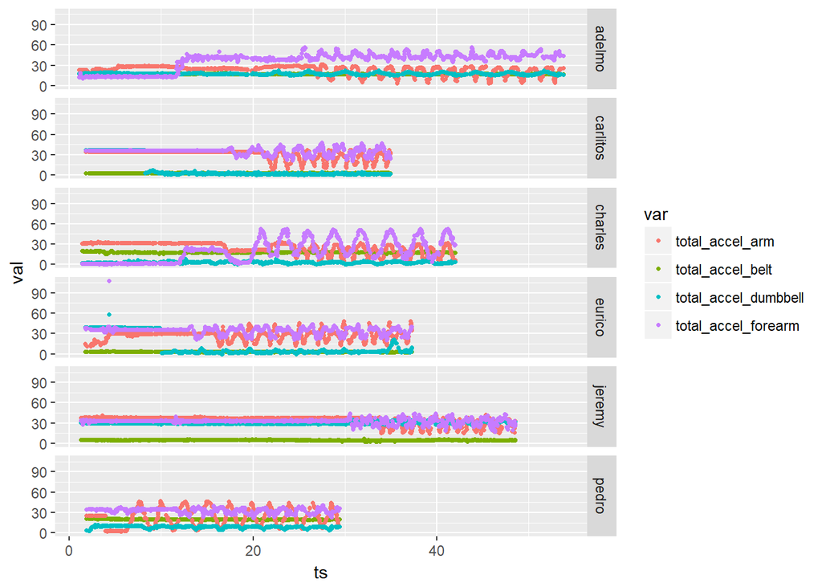

```r
dfAux <- dfTrain_Long %>%
  filter( classe == "A") %>%
  filter( var %in% c("total_accel_belt", "total_accel_arm", "total_accel_dumbbell", "total_accel_forearm" ))


pltChart <- ggplot(dfAux
               ,aes(x=ts, y=val, color=var)) +
    geom_point(shape=20) +
    facet_grid( user_name ~ . )

pltChart
```

### featurePlot

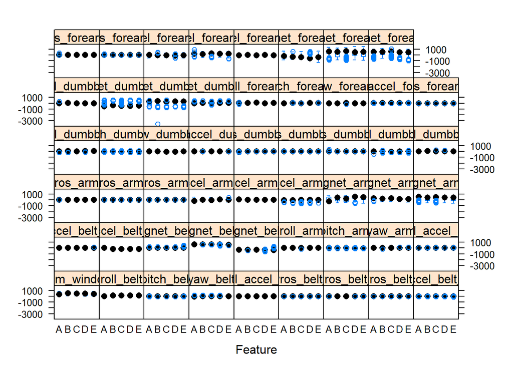

```r
featurePlot( x = dfTrain_X %>%
               select(-user_name
                      , -raw_timestamp_part_1, -raw_timestamp_part_2
                      )
            ,y = dfTrain_Y$classe
            ,plot = "box"
)
```

```r
#                      , -raw_timestamp_part_1, -raw_timestamp_part_2
```

## Pre-Processing

### Zero and Near-Zero variability, and correlation between predictors

Zero and Near-Zero variability variables:

```
## [1] col           freqRatio     percentUnique zeroVar       nzv
## <0 rows> (or 0-length row.names)
```

```
## $linearCombos
## list()
##
## $remove
## NULL
```

Variables to be ommited because of linear correlation:

```
##  [1] "accel_belt_z"      "roll_belt"         "accel_belt_y"
##  [4] "accel_arm_y"       "total_accel_belt"  "accel_dumbbell_z"
##  [7] "accel_belt_x"      "magnet_belt_x"     "magnet_dumbbell_x"
## [10] "accel_dumbbell_y"  "magnet_dumbbell_y" "magnet_dumbbell_z"
## [13] "accel_arm_x"       "accel_dumbbell_x"  "accel_arm_z"
## [16] "magnet_arm_y"      "magnet_belt_z"     "accel_forearm_y"
## [19] "gyros_forearm_z"   "gyros_dumbbell_z"  "gyros_arm_x"
```

PCA transformation seems to emphasize the difference between users instead of difference wetween classes.

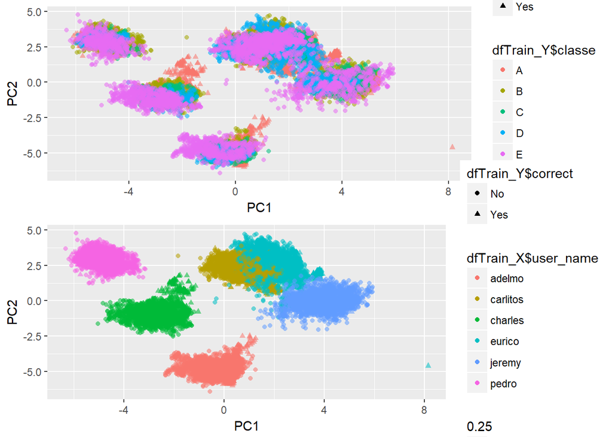

## Models

### Model Random Forest

> user system elapsed 43.64 0.44 88.46 Random Forest

> 19216 samples 35 predictor 2 classes: ‘No’, ‘Yes’

> No pre-processing Resampling: Cross-Validated (8 fold) Summary of sample sizes: 2403, 2402, 2402, 2402, 2402, 2401, … Resampling results across tuning parameters:

> mtry Accuracy Kappa  
> 2 0.9859938 0.9651365 20 0.9932125 0.9832885 39 0.9887074 0.9720965

> Accuracy was used to select the optimal model using the largest value. The final value used for the model was mtry = 20.

### Model GLM

```
## Warning: glm.fit: fitted probabilities numerically 0 or 1 occurred
```

```
##    user  system elapsed
##   15.32    5.80    6.14
```

```
## Generalized Linear Model
##
## 19216 samples
##    35 predictor
##     2 classes: 'No', 'Yes'
##
## No pre-processing
## Resampling: Cross-Validated (8 fold)
## Summary of sample sizes: 2402, 2401, 2402, 2403, 2402, 2402, ...
## Resampling results:
##
##   Accuracy   Kappa
##   0.9934058  0.9838615
```

- Note:
  - We will accept the model even with several warnings on potential colinearity since:
    - we droped variables with high correlation
    - the cross-validation accuracy is still high
  - So we migth have overfitting (or perfect predictions) on some cases but not in a scale that invalidate the prediction
  - On the other hand, we have 2402 cros-valitation test cases for 35 predictors, so we bet most likely it’s a good prediction and not overfitting.
  - The same goes for LDA

### Model GBM

```
##    user  system elapsed
##   22.91    0.02   23.09
```

```
## Stochastic Gradient Boosting
##
## 19216 samples
##    35 predictor
##     2 classes: 'No', 'Yes'
##
## No pre-processing
## Resampling: Cross-Validated (8 fold)
## Summary of sample sizes: 2402, 2401, 2402, 2403, 2402, 2402, ...
## Resampling results across tuning parameters:
##
##   interaction.depth  n.trees  Accuracy   Kappa
##   1                   50      0.8730894  0.6439924
##   1                  100      0.9090192  0.7563243
##   1                  150      0.9304374  0.8184028
##   2                   50      0.9271663  0.8079022
##   2                  100      0.9686347  0.9209132
##   2                  150      0.9839345  0.9600773
##   3                   50      0.9604347  0.8991954
##   3                  100      0.9858154  0.9648123
##   3                  150      0.9937329  0.9845656
##
## Tuning parameter 'shrinkage' was held constant at a value of 0.1
##
## Tuning parameter 'n.minobsinnode' was held constant at a value of 10
## Accuracy was used to select the optimal model using the largest value.
## The final values used for the model were n.trees = 150,
##  interaction.depth = 3, shrinkage = 0.1 and n.minobsinnode = 10.
```

### Model LDA

```
##    user  system elapsed
##    4.21    1.55    1.89
```

```
## Linear Discriminant Analysis
##
## 19216 samples
##    35 predictor
##     2 classes: 'No', 'Yes'
##
## No pre-processing
## Resampling: Cross-Validated (8 fold)
## Summary of sample sizes: 2402, 2401, 2402, 2403, 2402, 2402, ...
## Resampling results:
##
##   Accuracy   Kappa
##   0.8344237  0.5537862
```

### Model Stacked

```r
vTrainGLM <- predict(mdlGLM,  dfTrain_XY)
vTrainLDA <- predict(mdlLDA, dfTrain_XY)

vTrainGBM <- predict(mdlGBM, dfTrain_XY)

# comparing bothe predictions
# confusionMatrix(vTrainGLM, vTrainLDA)
# confusionMatrix(vTrainGLM, vTrainGBM)
# confusionMatrix(vTrainLDA, vTrainGBM)

dfStacked_Train <- tibble( correct = dfTrain_XY$correct
                           ,user_name = dfTrain_XY$user_name
                           ,glm = vTrainGLM
                           ,lda = vTrainLDA
                           ,gbm = vTrainGBM
)
```

```r
cl <- makePSOCKcluster(4)

registerDoParallel(cl)

set.seed(33833)
system.time(mdlStacked <- train(correct ~ .
                    , method="rf"
                    , trControl = ctrlFolds
                    , data=dfStacked_Train))
```

```
##    user  system elapsed
##    4.75    0.34   14.45
```

```r
stopCluster(cl)


mdlStacked
```

```
## Random Forest
##
## 19216 samples
##     4 predictor
##     2 classes: 'No', 'Yes'
##
## No pre-processing
## Resampling: Cross-Validated (8 fold)
## Summary of sample sizes: 2402, 2401, 2402, 2403, 2402, 2402, ...
## Resampling results across tuning parameters:
##
##   mtry  Accuracy   Kappa
##   2     0.9984165  0.9961121
##   5     0.9984388  0.9961670
##   8     0.9984685  0.9962399
##
## Accuracy was used to select the optimal model using the largest value.
## The final value used for the model was mtry = 8.
```

## Apply to Test

Prediction: * Yes : correcto (classe “A”) * No : incorrect

```r
vTestGLM <- predict(mdlGLM,  dfTest)
vTestLDA <- predict(mdlLDA, dfTest)

vTestGBM <- predict(mdlGBM, dfTest)

dfStacked_Test <- tibble(   user_name = dfTest$user_name
                           ,glm = vTestGLM
                           ,lda = vTestLDA
                           ,gbm = vTestGBM
)


vTest_Stacked <- predict(mdlStacked, dfStacked_Test)

dfStacked_TestXY <- dfStacked_Test %>%
  mutate(result = vTest_Stacked)

dfResult <- dfTest %>%
  mutate(problem_id = dfTest_Read$problem_id
         ,prediction = vTest_Stacked
         ) %>%
  select(problem_id, prediction
         ,user_name, num_window
         )
dfResult
```

```
## # A tibble: 20 x 4
##    problem_id prediction user_name num_window
##    <chr>      <fct>      <fct>          <int>
##  1 1          No         pedro             74
##  2 2          Yes        jeremy           431
##  3 3          No         jeremy           439
##  4 4          Yes        adelmo           194
##  5 5          Yes        eurico           235
##  6 6          No         jeremy           504
##  7 7          No         jeremy           485
##  8 8          No         jeremy           440
##  9 9          Yes        carlitos         323
## 10 10         Yes        charles          664
## 11 11         No         carlitos         859
## 12 12         No         jeremy           461
## 13 13         No         eurico           257
## 14 14         Yes        jeremy           408
## 15 15         No         jeremy           779
## 16 16         No         eurico           302
## 17 17         Yes        pedro             48
## 18 18         No         carlitos         361
## 19 19         No         pedro             72
## 20 20         No         eurico           255
```